# Deskriptivní statistika

- Cíle:
  - Popis dat do práce
  - Nalezení nesrovnalostí a chyb v datech
  - Porovnání tržních a modelových cen

## 0 – Global overview

```r
cat("Rows:", nrow(df), "| Columns:", ncol(df), "| Unique tickers:", n_distinct(df$ticker))
```

```
## Rows: 168996 | Columns: 21 | Unique tickers: 18
```

```r
kable(
  df %>% count(am_eu, call_put),
  caption = "Počet opcí na kategorii"
)
```

Počet opcí na kategorii

| am_eu | call_put | n |
| --- | --- | --- |
| american | calls | 78863 |
| american | puts | 68537 |
| european | calls | 10467 |
| european | puts | 11129 |

```r
num_cols <- c("S", "K", "r", "sigma", "T", "q", "true_price")
df_filtered <- df[df$true_price > 0, ]
summary_rows <- lapply(num_cols, function(col) {
  vals <- df_filtered[[col]]
  data.frame(
    column = col,
    n = sum(!is.na(vals)),
    na = sum(is.na(vals)),
    mean = mean(vals, na.rm = TRUE),
    sd = sd(vals, na.rm = TRUE),
    min = min(vals, na.rm = TRUE),
    median = median(vals, na.rm = TRUE),
    max = max(vals, na.rm = TRUE)
  )
})
kable(bind_rows(summary_rows), digits = 4, caption = "Globální summary všech numerických sloupců")
```

Globální summary všech numerických sloupců

| column | n | na | mean | sd | min | median | max |
| --- | --- | --- | --- | --- | --- | --- | --- |
| S | 168993 | 0 | 541.3005 | 738.8464 | 16.0900 | 307.3800 | 2869.2300 |
| K | 168993 | 0 | 616.2133 | 753.8150 | 0.5000 | 325.0000 | 5000.0000 |
| r | 168993 | 0 | 0.0371 | 0.0013 | 0.0338 | 0.0374 | 0.0406 |
| sigma | 168993 | 0 | 0.3878 | 0.1971 | 0.0629 | 0.3389 | 1.3825 |
| T | 168993 | 0 | 0.6611 | 0.7134 | 0.0027 | 0.3945 | 2.8904 |
| q | 168993 | 0 | 0.0022 | 0.0063 | 0.0000 | 0.0000 | 0.1360 |
| true_price | 168993 | 0 | 80.1734 | 140.4778 | 0.0100 | 22.3500 | 1848.0000 |

- Vysoké sigma pro ^VIX. VIX je index nad volatilitou. Musíme si dávat pozor, ale nemělo by být moc problémové.
- KO obsahuje vysoké hodnoty pro `q` (0.136, 0.101). Podezřelé, nutno potom zkontrolovat. (Vysoké dividendy? 10 % je fakt hodně…)

```r
ticker_summary <- df %>%
  group_by(ticker) %>%
  summarise(
    n = n(),
    S_mean = mean(S, na.rm = TRUE),
    S_min  = min(S, na.rm = TRUE),
    S_max  = max(S, na.rm = TRUE),
    K_mean = mean(K, na.rm = TRUE),
    K_min  = min(K, na.rm = TRUE),
    K_max  = max(K, na.rm = TRUE),
    sigma_mean = mean(sigma, na.rm = TRUE),
    sigma_min  = min(sigma, na.rm = TRUE),
    sigma_max  = max(sigma, na.rm = TRUE),
    T_min  = min(T, na.rm = TRUE),
    T_max  = max(T, na.rm = TRUE),
    q_mean = mean(q, na.rm = TRUE),
    price_mean = mean(true_price, na.rm = TRUE),
    price_min  = min(true_price, na.rm = TRUE),
    price_max  = max(true_price, na.rm = TRUE),
    .groups = "drop"
  ) %>%
  arrange(desc(n))
kable(ticker_summary, digits = 2, caption = "Per-ticker summary (seřazeno dle počtu opcí)")
```

Per-ticker summary (seřazeno dle počtu opcí)

| ticker | n | S_mean | S_min | S_max | K_mean | K_min | K_max | sigma_mean | sigma_min | sigma_max | T_min | T_max | q_mean | price_mean | price_min | price_max |
| --- | --- | --- | --- | --- | --- | --- | --- | --- | --- | --- | --- | --- | --- | --- | --- | --- |
| NFLX | 25755 | 88.02 | 84.59 | 93.32 | 562.53 | 0.5 | 2660 | 0.33 | 0.33 | 0.34 | 0.00 | 2.89 | 0.00 | 94.77 | 0.00 | 1467.16 |
| META | 20250 | 617.85 | 547.54 | 658.76 | 673.37 | 5.0 | 1500 | 0.38 | 0.35 | 0.39 | 0.00 | 2.89 | 0.00 | 109.78 | 0.01 | 943.00 |
| TSLA | 20143 | 414.01 | 372.11 | 449.06 | 434.14 | 5.0 | 990 | 0.56 | 0.47 | 0.62 | 0.00 | 2.89 | 0.00 | 105.34 | 0.01 | 648.20 |
| ^RUT | 17060 | 2685.37 | 2493.32 | 2869.23 | 2519.62 | 950.0 | 5000 | 0.22 | 0.19 | 0.23 | 0.00 | 2.89 | 0.00 | 108.17 | 0.01 | 1848.00 |
| NVDA | 15611 | 190.74 | 171.24 | 215.33 | 326.06 | 0.5 | 2500 | 0.41 | 0.34 | 0.49 | 0.00 | 2.89 | 0.00 | 92.85 | 0.01 | 1209.78 |
| GOOGL | 13970 | 327.61 | 280.92 | 382.97 | 306.51 | 5.0 | 800 | 0.30 | 0.29 | 0.32 | 0.00 | 2.89 | 0.00 | 58.77 | 0.01 | 415.00 |
| MSFT | 12453 | 412.27 | 365.97 | 465.95 | 458.04 | 175.0 | 800 | 0.25 | 0.24 | 0.27 | 0.00 | 2.89 | 0.01 | 60.77 | 0.01 | 418.75 |
| AMD | 11841 | 308.65 | 203.68 | 467.51 | 289.14 | 5.0 | 930 | 0.62 | 0.59 | 0.64 | 0.00 | 2.89 | 0.00 | 80.45 | 0.01 | 547.35 |
| AAPL | 10020 | 272.00 | 248.04 | 308.82 | 240.68 | 5.0 | 600 | 0.29 | 0.22 | 0.32 | 0.00 | 2.89 | 0.00 | 44.15 | 0.01 | 304.39 |
| AMZN | 8321 | 231.04 | 207.54 | 266.32 | 226.47 | 75.0 | 410 | 0.33 | 0.30 | 0.35 | 0.00 | 2.89 | 0.00 | 36.68 | 0.01 | 193.50 |
| ^VIX | 4296 | 19.61 | 16.09 | 27.44 | 44.22 | 10.0 | 200 | 1.31 | 1.14 | 1.38 | 0.01 | 0.66 | 0.00 | 9.57 | 0.01 | 181.45 |
| JNJ | 3428 | 234.63 | 220.14 | 243.47 | 191.99 | 75.0 | 360 | 0.19 | 0.16 | 0.20 | 0.00 | 1.99 | 0.01 | 27.08 | 0.01 | 173.92 |
| PG | 2870 | 149.99 | 142.42 | 163.75 | 146.85 | 70.0 | 260 | 0.19 | 0.18 | 0.19 | 0.00 | 1.99 | 0.01 | 12.46 | 0.01 | 114.99 |
| KO | 2738 | 77.55 | 72.88 | 81.48 | 70.58 | 32.5 | 120 | 0.17 | 0.16 | 0.18 | 0.00 | 1.99 | 0.02 | 7.17 | 0.01 | 50.00 |
| ^XDE | 92 | 116.96 | 115.34 | 118.23 | 117.95 | 110.0 | 123 | 0.07 | 0.06 | 0.08 | 0.06 | 0.81 | 0.00 | 2.60 | 0.34 | 7.58 |
| ^XDN | 66 | 63.50 | 62.63 | 64.23 | 68.26 | 62.0 | 80 | 0.10 | 0.09 | 0.10 | 0.06 | 0.90 | 0.00 | 1.48 | 0.10 | 4.60 |
| ^XDB | 47 | 134.88 | 133.37 | 136.44 | 132.49 | 120.0 | 140 | 0.07 | 0.07 | 0.07 | 0.06 | 0.82 | 0.00 | 3.28 | 0.15 | 7.20 |
| ^XDA | 35 | 70.32 | 68.91 | 71.28 | 67.74 | 53.0 | 75 | 0.09 | 0.08 | 0.10 | 0.06 | 0.90 | 0.00 | 3.47 | 1.33 | 12.45 |

## 1 – Coverage

```r
kable(
  df %>% count(am_eu, call_put),
  caption = "Počet opcí na kategorii"
)
```

Počet opcí na kategorii

| am_eu | call_put | n |
| --- | --- | --- |
| american | calls | 78863 |
| american | puts | 68537 |
| european | calls | 10467 |
| european | puts | 11129 |

```r
ticker_cat_counts <- df %>%
  count(ticker, call_put) %>%
  pivot_wider(names_from = call_put, values_from = n, values_fill = 0)
kable(ticker_cat_counts, caption = "Počet opcí na ticker × call/put")
```

Počet opcí na ticker × call/put

| ticker | calls | puts |
| --- | --- | --- |
| AAPL | 5374 | 4646 |
| AMD | 6249 | 5592 |
| AMZN | 4316 | 4005 |
| GOOGL | 7671 | 6299 |
| JNJ | 1791 | 1637 |
| KO | 1394 | 1344 |
| META | 11119 | 9131 |
| MSFT | 6453 | 6000 |
| NFLX | 14431 | 11324 |
| NVDA | 8173 | 7438 |
| PG | 1460 | 1410 |
| TSLA | 10432 | 9711 |
| ^RUT | 7804 | 9256 |
| ^VIX | 2519 | 1777 |
| ^XDA | 35 | 0 |
| ^XDB | 1 | 46 |
| ^XDE | 53 | 39 |
| ^XDN | 55 | 11 |

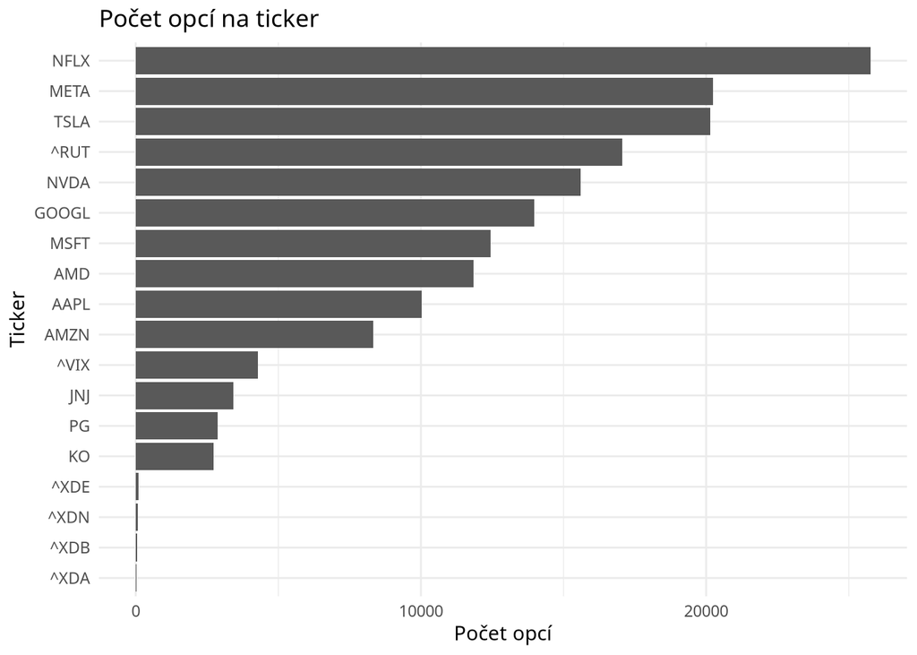

```r
df %>%
  count(ticker) %>%
  ggplot(aes(x = reorder(ticker, n), y = n)) +
  geom_col() +
  coord_flip() +
  labs(x = "Ticker", y = "Počet opcí", title = "Počet opcí na ticker") +
  theme_minimal()
```

```r
ggsave("../figures/descriptive_coverage_by_ticker.pdf", width = 8, height = 5)
```

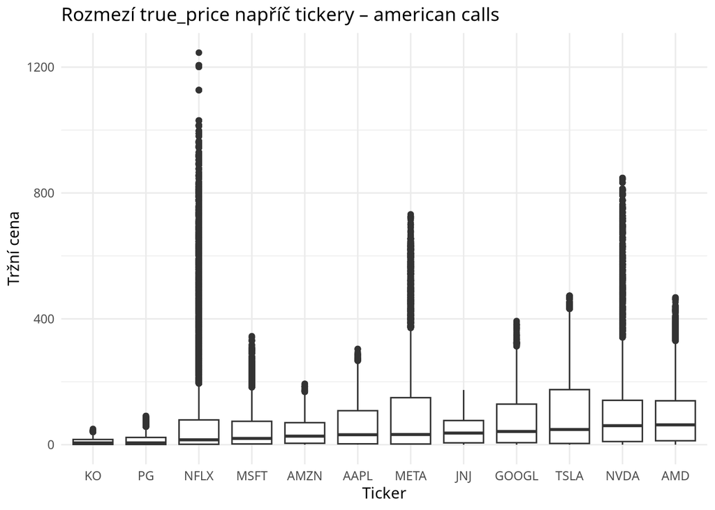

```r
df %>%
  filter(am_eu == "american", call_put == "calls") %>%
  ggplot(aes(x = reorder(ticker, true_price, FUN = median), y = true_price)) +
  geom_boxplot() +
  labs(x = "Ticker", y = "Tržní cena", title = "Rozmezí true_price napříč tickery – american calls") +
  theme_minimal()
```

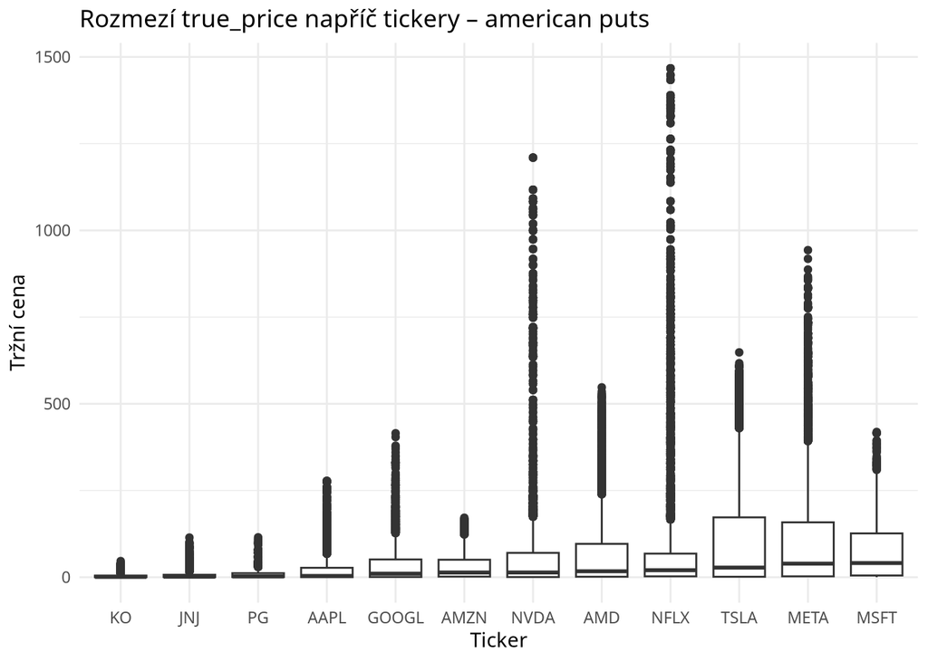

```r
ggsave("../figures/descriptive_price_by_ticker_american_calls.pdf", width = 10, height = 6)
df %>%
  filter(am_eu == "american", call_put == "puts") %>%
  ggplot(aes(x = reorder(ticker, true_price, FUN = median), y = true_price)) +
  geom_boxplot() +
  labs(x = "Ticker", y = "Tržní cena", title = "Rozmezí true_price napříč tickery – american puts") +
  theme_minimal()
```

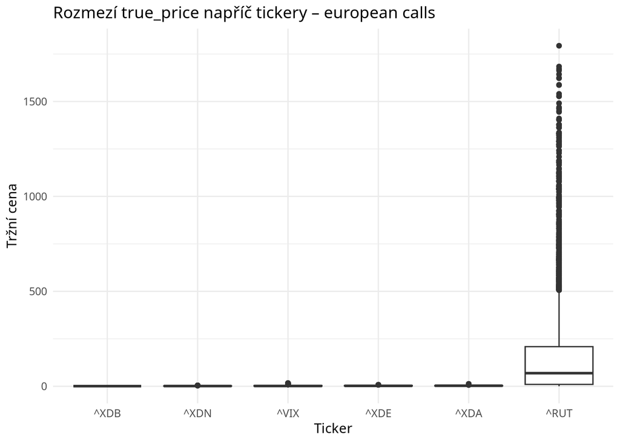

```r
ggsave("../figures/descriptive_price_by_ticker_american_puts.pdf", width = 10, height = 6)
df %>%
  filter(am_eu == "european", call_put == "calls") %>%
  ggplot(aes(x = reorder(ticker, true_price, FUN = median), y = true_price)) +
  geom_boxplot() +
  labs(x = "Ticker", y = "Tržní cena", title = "Rozmezí true_price napříč tickery – european calls") +
  theme_minimal()
```

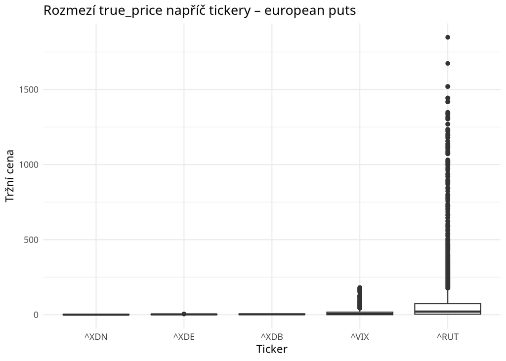

```r
ggsave("../figures/descriptive_price_by_ticker_european_calls.pdf", width = 10, height = 6)
df %>%
  filter(am_eu == "european", call_put == "puts") %>%
  ggplot(aes(x = reorder(ticker, true_price, FUN = median), y = true_price)) +
  geom_boxplot() +
  labs(x = "Ticker", y = "Tržní cena", title = "Rozmezí true_price napříč tickery – european puts") +
  theme_minimal()
```

```r
ggsave("../figures/descriptive_price_by_ticker_european_puts.pdf", width = 10, height = 6)
```

## 2 – Distribuce vstupních parametrů

```r
param_data <- df %>% distinct(ticker, S, K, r, sigma, T, q, am_eu, call_put)

param_summary <- param_data %>%
  group_by(am_eu, call_put) %>%
  summarise(
    across(c(S, K, r, sigma, T, q),
           list(mean = ~ mean(., na.rm = TRUE),
                sd   = ~ sd(., na.rm = TRUE),
                min  = ~ min(., na.rm = TRUE),
                median = ~ median(., na.rm = TRUE),
                max  = ~ max(., na.rm = TRUE)),
           .names = "{.col}_{.fn}"),
    .groups = "drop"
  )
kable(param_summary, digits = 4, caption = "Summary statistika parametrů dle kategorie")
```

Summary statistika parametrů dle kategorie

| am_eu | call_put | S_mean | S_sd | S_min | S_median | S_max | K_mean | K_sd | K_min | K_median | K_max | r_mean | r_sd | r_min | r_median | r_max | sigma_mean | sigma_sd | sigma_min | sigma_median | sigma_max | T_mean | T_sd | T_min | T_median | T_max | q_mean | q_sd | q_min | … |
| --- | --- | --- | --- | --- | --- | --- | --- | --- | --- | --- | --- | --- | --- | --- | --- | --- | --- | --- | --- | --- | --- | --- | --- | --- | --- | --- | --- | --- | --- | --- |
| american | calls | 308.7655 | 173.3366 | 72.88 | 272.95 | 658.76 | 451.0079 | 440.8162 | 0.5 | 315 | 2660 | 0.0371 | 0.0013 | 0.0338 | 0.0374 | 0.0406 | 0.3797 | 0.1242 | 0.1561 | 0.3419 | 0.6353 | 0.7184 | 0.7292 | 0.0027 | 0.4822 | 2.8904 | 0.0025 | 0.0066 | 0 | … |
| american | puts | 309.4036 | 169.8347 | 72.88 | 280.92 | 658.76 | 370.1544 | 340.0318 | 0.5 | 270 | 2660 | 0.0371 | 0.0013 | 0.0338 | 0.0374 | 0.0406 | 0.3819 | 0.1273 | 0.1561 | 0.3419 | 0.6353 | 0.7249 | 0.7325 | 0.0027 | 0.4822 | 2.8904 | 0.0026 | 0.0069 | 0 | … |
| european | calls | 2007.8446 | 1165.3451 | 16.09 | 2669.16 | 2869.23 | 2006.8341 | 1197.6686 | 10.0 | 2580 | 5000 | 0.0373 | 0.0008 | 0.0339 | 0.0375 | 0.0406 | 0.4810 | 0.4709 | 0.0629 | 0.2309 | 1.3825 | 0.2505 | 0.3593 | 0.0027 | 0.0986 | 2.8904 | 0.0000 | 0.0000 | 0 | … |
| european | puts | 2237.7909 | 1003.2685 | 16.09 | 2669.16 | 2869.23 | 1994.1689 | 952.3529 | 10.0 | 2360 | 5000 | 0.0374 | 0.0008 | 0.0339 | 0.0375 | 0.0406 | 0.3935 | 0.4041 | 0.0629 | 0.2309 | 1.3825 | 0.2474 | 0.3936 | 0.0027 | 0.0904 | 2.8904 | 0.0000 | 0.0000 | 0 | … |

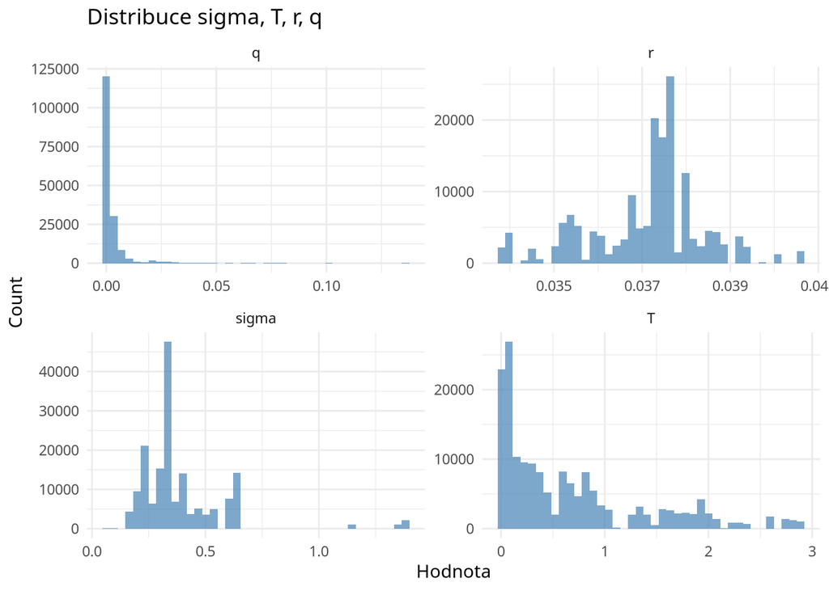

```r
h_data <- param_data %>%
  pivot_longer(cols = c(sigma, T, r, q), names_to = "param", values_to = "value")

ggplot(h_data, aes(x = value)) +
  geom_histogram(bins = 40, fill = "steelblue", alpha = 0.7) +
  facet_wrap(~ param, scales = "free", ncol = 2) +
  labs(x = "Hodnota", y = "Count", title = "Distribuce sigma, T, r, q") +
  theme_minimal()
```

```r
ggsave("../figures/descriptive_param_histograms.pdf", width = 8, height = 6)
```

`q` je rozumně rozložené, většina v 0. Pár opcí na mezi 0.10 - 0.15 a 0.05 - 0.1, což je podezřelé.

`r` má pro všechny opce rozumnou hodnotu.

`sigma` nabývá od pohledu rozumných hodnot, většinou 0.3 - 0.7. Jsou tam nějaké které vypadají na 0.10 - 0.20 a 1+, nutno prozkoumat.

## 3 – Moneyness & time profily

```r
regime_counts <- df %>%
  count(am_eu, call_put, moneyness_regime, time_regime) %>%
  pivot_wider(names_from = time_regime, values_from = n, values_fill = 0)
kable(regime_counts, caption = "Počet opcí dle moneyness a time regime")
```

Počet opcí dle moneyness a time regime

| am_eu | call_put | moneyness_regime | Long | Medium | Short |
| --- | --- | --- | --- | --- | --- |
| american | calls | ATM | 1998 | 1450 | 2984 |
| american | calls | ITM | 15115 | 8050 | 7024 |
| american | calls | OTM | 21006 | 11248 | 9988 |
| american | puts | ATM | 1975 | 1426 | 2993 |
| american | puts | ITM | 15375 | 7883 | 5510 |
| american | puts | OTM | 16036 | 8733 | 8606 |
| european | calls | ATM | 336 | 703 | 2223 |
| european | calls | ITM | 584 | 1086 | 1126 |
| european | calls | OTM | 736 | 1669 | 2004 |
| european | puts | ATM | 248 | 688 | 1903 |
| european | puts | ITM | 369 | 714 | 673 |
| european | puts | OTM | 1000 | 2116 | 3418 |

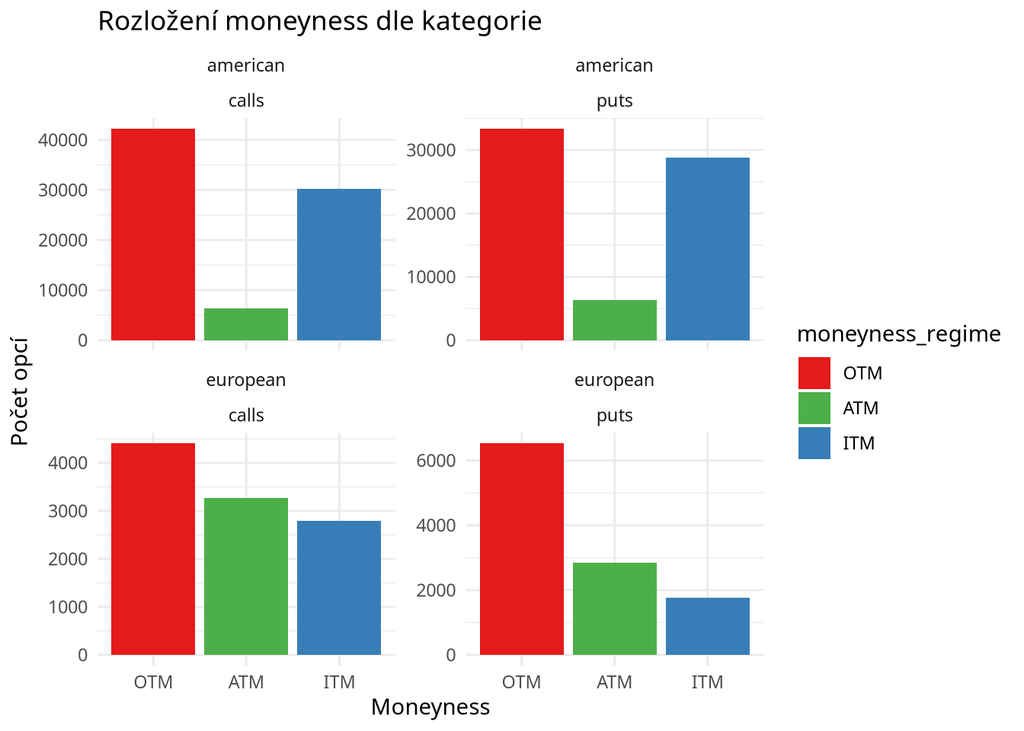

```r
df %>%
  count(am_eu, call_put, moneyness_regime) %>%
  mutate(moneyness_regime = factor(moneyness_regime, c("OTM", "ATM", "ITM"))) %>%
  ggplot(aes(x = moneyness_regime, y = n, fill = moneyness_regime)) +
  geom_col() +
  facet_wrap(~ am_eu + call_put, scales = "free_y") +
  labs(x = "Moneyness", y = "Počet opcí", title = "Rozložení moneyness dle kategorie") +
  scale_fill_manual(values = c("OTM" = "#E41A1C", "ATM" = "#4DAF4A", "ITM" = "#377EB8")) +
  theme_minimal()
```

```r
ggsave("../figures/descriptive_moneyness_bar.pdf", width = 8, height = 6)
```

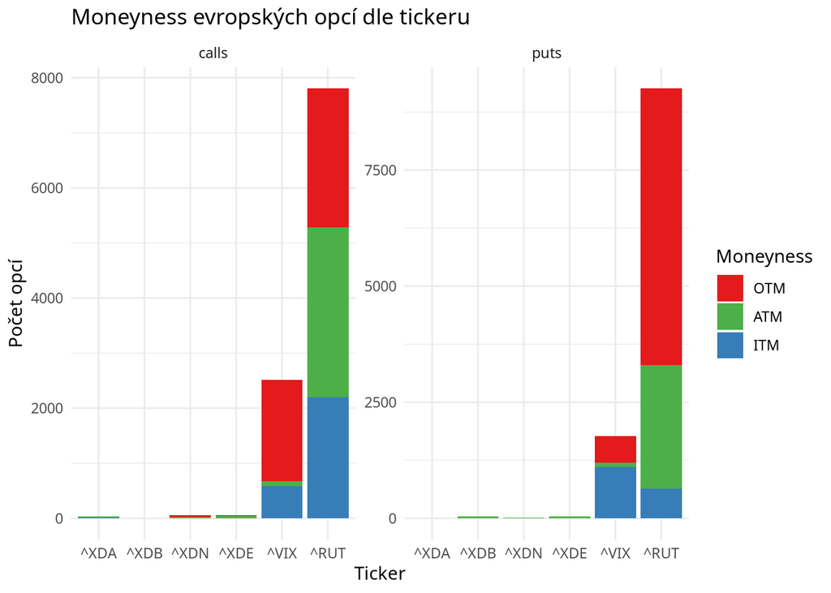

```r
df %>%
  filter(am_eu == "european") %>%
  count(ticker, call_put, moneyness_regime) %>%
  mutate(moneyness_regime = factor(moneyness_regime, c("OTM", "ATM", "ITM"))) %>%
  ggplot(aes(x = reorder(ticker, n, sum), y = n, fill = moneyness_regime)) +
  geom_col() +
  facet_wrap(~ call_put, scales = "free_y") +
  scale_fill_manual(values = c("OTM" = "#E41A1C", "ATM" = "#4DAF4A", "ITM" = "#377EB8")) +
  labs(x = "Ticker", y = "Počet opcí", fill = "Moneyness",
       title = "Moneyness evropských opcí dle tickeru") +
  theme_minimal()
```

```r
ggsave("../figures/descriptive_moneyness_european_by_ticker.pdf", width = 8, height = 5)
```

## 4 – Ceny: trh vs model

```r
price_summary <- df_model %>%
  group_by(am_eu, call_put, model) %>%
  summarise(
    across(c(true_price, teor_price),
           list(mean = ~ mean(., na.rm = TRUE),
                sd   = ~ sd(., na.rm = TRUE),
                min  = ~ min(., na.rm = TRUE),
                median = ~ median(., na.rm = TRUE),
                max  = ~ max(., na.rm = TRUE)),
           .names = "{.col}_{.fn}"),
    .groups = "drop"
  )
kable(price_summary, digits = 4, caption = "Summary true_price a teor_price dle kategorie a modelu")
```

Summary true_price a teor_price dle kategorie a modelu

| am_eu | call_put | model | true_price_mean | true_price_sd | true_price_min | true_price_median | true_price_max | teor_price_mean | teor_price_sd | teor_price_min | teor_price_median | teor_price_max |
| --- | --- | --- | --- | --- | --- | --- | --- | --- | --- | --- | --- | --- |
| american | calls | bs | 85.0272 | 131.6066 | 0.01 | 31.02 | 1246.00 | 61.7214 | 96.2057 | 0 | 17.8800 | 653.7735 |
| american | calls | crr | 85.0272 | 131.6066 | 0.01 | 31.02 | 1246.00 | 61.7212 | 96.2059 | 0 | 17.8731 | 653.7735 |
| american | calls | mc | 85.0272 | 131.6066 | 0.01 | 31.02 | 1246.00 | 61.7165 | 96.1746 | 0 | 17.9500 | 656.9891 |
| american | puts | bs | 72.3135 | 136.7892 | 0.00 | 15.38 | 1467.16 | 133.8883 | 302.3406 | 0 | 16.4000 | 2575.4100 |
| american | puts | crr | 72.3135 | 136.7892 | 0.00 | 15.38 | 1467.16 | 133.9312 | 302.3653 | 0 | 16.3413 | 2575.4100 |
| american | puts | mc | 72.3135 | 136.7892 | 0.00 | 15.38 | 1467.16 | 133.8502 | 302.1240 | 0 | 16.4032 | 2573.6177 |
| european | calls | bs | 116.0201 | 204.7467 | 0.01 | 21.85 | 1793.65 | 142.7447 | 261.2161 | 0 | 22.5784 | 1939.4976 |
| european | calls | crr | 116.0201 | 204.7467 | 0.01 | 21.85 | 1793.65 | 142.7580 | 261.2208 | 0 | 22.5489 | 1939.4976 |
| european | calls | mc | 116.0201 | 204.7467 | 0.01 | 21.85 | 1793.65 | 142.7441 | 261.2172 | 0 | 22.5760 | 1939.3569 |
| european | puts | bs | 60.4457 | 141.8714 | 0.01 | 15.82 | 1848.00 | 45.3991 | 107.5364 | 0 | 6.0204 | 1671.7577 |
| european | puts | crr | 60.4457 | 141.8714 | 0.01 | 15.82 | 1848.00 | 45.4111 | 107.5391 | 0 | 6.0073 | 1670.8074 |
| european | puts | mc | 60.4457 | 141.8714 | 0.01 | 15.82 | 1848.00 | 45.4005 | 107.5352 | 0 | 6.0490 | 1672.3252 |

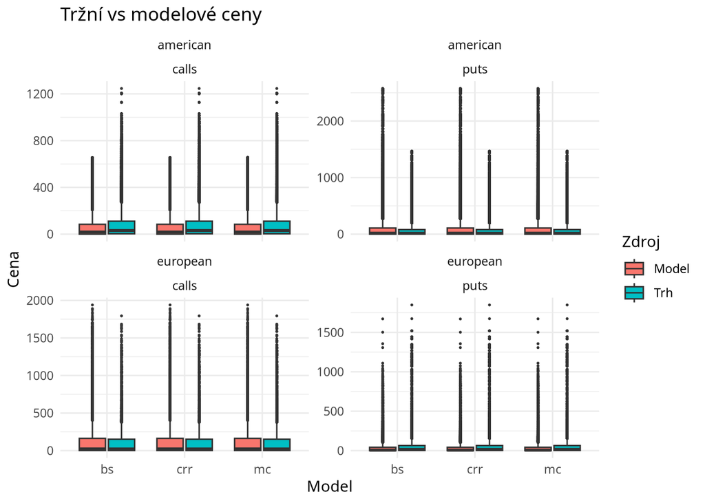

```r
df_model %>%
  pivot_longer(cols = c(true_price, teor_price), names_to = "type", values_to = "price") %>%
  mutate(type = recode(type, true_price = "Trh", teor_price = "Model")) %>%
  ggplot(aes(x = model, y = price, fill = type)) +
  geom_boxplot(outlier.size = 0.3) +
  facet_wrap(~ am_eu + call_put, scales = "free_y") +
  labs(x = "Model", y = "Cena", title = "Tržní vs modelové ceny", fill = "Zdroj") +
  theme_minimal()
```

```r
ggsave("../figures/descriptive_price_boxplot.pdf", width = 10, height = 8)
```

Pro americké opce, call opce jsou modely podhodnoceny a put opce jsou nadhodnoceny. Pro evropské opce je to právě naopak.

## 5 – Relativní chyba

```r
rel_summary <- df_model %>%
  group_by(am_eu, call_put, model) %>%
  summarise(
    mean   = mean(rel_error, na.rm = TRUE),
    median = median(rel_error, na.rm = TRUE),
    sd     = sd(rel_error, na.rm = TRUE),
    q1     = quantile(rel_error, 0.25, na.rm = TRUE),
    q3     = quantile(rel_error, 0.75, na.rm = TRUE),
    p5     = quantile(rel_error, 0.05, na.rm = TRUE),
    p95    = quantile(rel_error, 0.95, na.rm = TRUE),
    .groups = "drop"
  )
kable(rel_summary, digits = 4, caption = "Summary relativní chyby dle kategorie a modelu")
```

Summary relativní chyby dle kategorie a modelu

| am_eu | call_put | model | mean | median | sd | q1 | q3 | p5 | p95 |
| --- | --- | --- | --- | --- | --- | --- | --- | --- | --- |
| american | calls | bs | -0.1981 | -0.0906 | 2.0965 | -0.5969 | 0.0103 | -1.0000 | 0.5074 |
| american | calls | crr | -0.2006 | -0.0909 | 2.0910 | -0.6053 | 0.0100 | -1.0000 | 0.5005 |
| american | calls | mc | -0.1739 | -0.0883 | 2.2781 | -0.5805 | 0.0136 | -1.0000 | 0.5403 |
| american | puts | bs | Inf | -0.1017 | NaN | -0.8474 | 0.0741 | -1.0000 | 4.6418 |
| american | puts | crr | 4.0961 | -0.1017 | 202.1829 | -0.8587 | 0.0744 | -1.0000 | 4.6382 |
| american | puts | mc | 4.1000 | -0.0973 | 201.9977 | -0.8527 | 0.0798 | -1.0000 | 4.6639 |
| european | calls | bs | 0.1236 | 0.0002 | 0.9584 | -0.3569 | 0.3927 | -0.9994 | 1.5633 |
| european | calls | crr | 0.1213 | -0.0009 | 0.9555 | -0.3595 | 0.3924 | -0.9996 | 1.5590 |
| european | calls | mc | 0.1243 | -0.0006 | 0.9636 | -0.3563 | 0.3952 | -1.0000 | 1.5733 |
| european | puts | bs | 1.4934 | -0.5421 | 14.4304 | -0.9816 | -0.0258 | -1.0000 | 1.9414 |
| european | puts | crr | 1.4938 | -0.5414 | 14.4349 | -0.9825 | -0.0253 | -1.0000 | 1.9333 |
| european | puts | mc | 1.4941 | -0.5408 | 14.4127 | -0.9814 | -0.0259 | -1.0000 | 1.9356 |

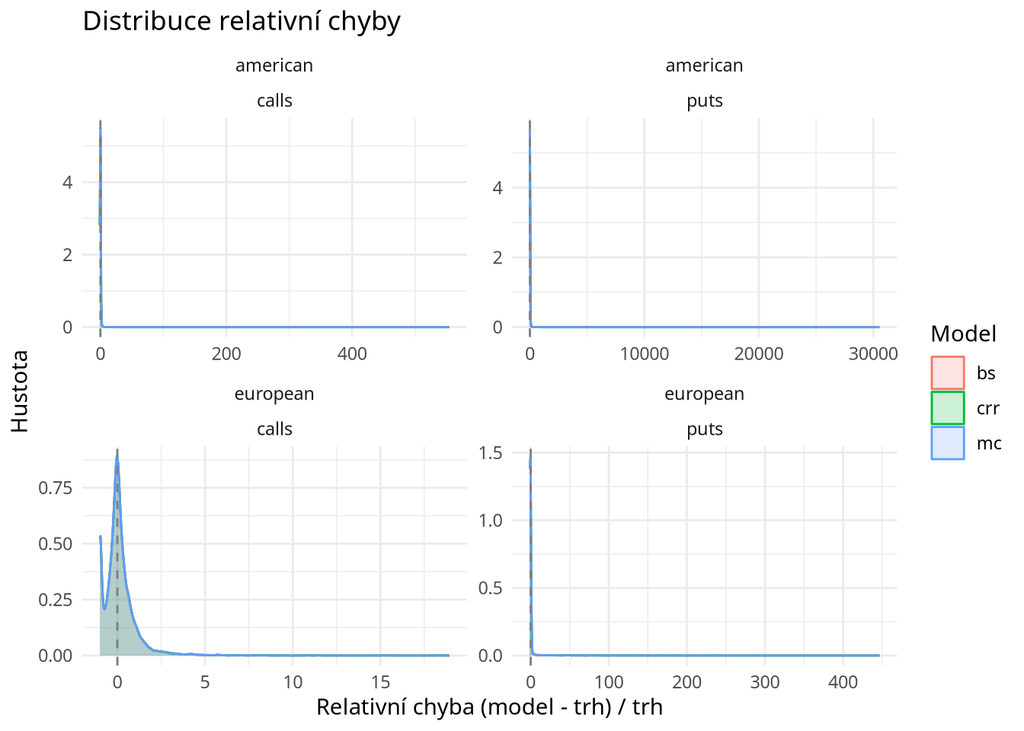

```r
df_model %>%
  ggplot(aes(x = rel_error, color = model, fill = model)) +
  geom_density(alpha = 0.2) +
  geom_vline(xintercept = 0, linetype = "dashed", color = "grey50") +
  facet_wrap(~ am_eu + call_put, scales = "free") +
  labs(x = "Relativní chyba (model - trh) / trh",
       y = "Hustota",
       title = "Distribuce relativní chyby",
       color = "Model", fill = "Model") +
  theme_minimal()
```

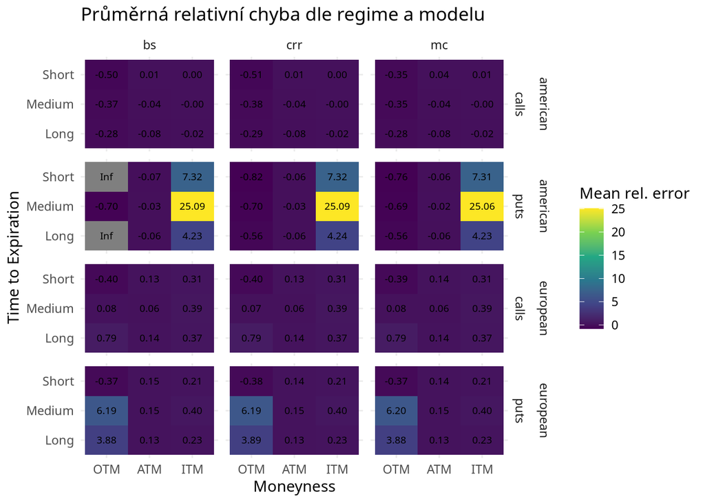

```r
ggsave("../figures/descriptive_rel_error_density.pdf", width = 10, height = 8)
rel_heatmap <- df_model %>%
  group_by(am_eu, call_put, model, moneyness_regime, time_regime) %>%
  summarise(mean_rel_err = mean(rel_error, na.rm = TRUE), .groups = "drop") %>%
  mutate(moneyness_regime = factor(moneyness_regime, c("OTM", "ATM", "ITM")))

ggplot(rel_heatmap, aes(x = moneyness_regime, y = time_regime, fill = mean_rel_err)) +
  geom_tile() +
  geom_text(aes(label = sprintf("%.2f", mean_rel_err)), size = 2.5) +
  facet_grid(am_eu + call_put ~ model) +
  scale_fill_viridis_c() +
  labs(x = "Moneyness", y = "Time to Expiration",
       title = "Průměrná relativní chyba dle regime a modelu",
       fill = "Mean rel. error") +
  theme_minimal()
```

```r
ggsave("../figures/descriptive_rel_error_heatmap.pdf", width = 10, height = 8)
```

## 6 – Převzato z results.Rmd

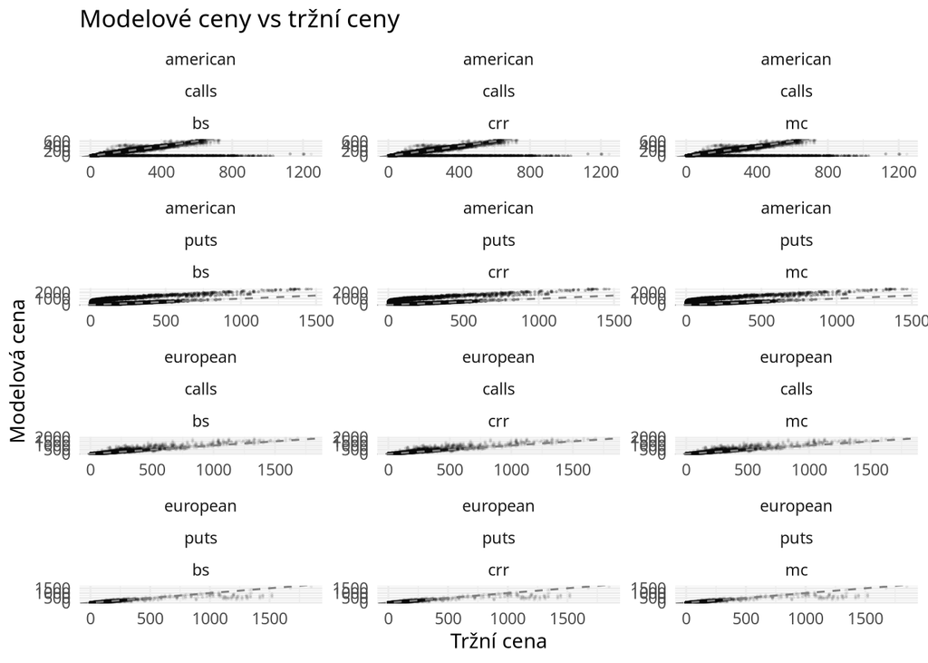

```r
df_model %>%
  ggplot(aes(x = true_price, y = teor_price)) +
  geom_point(alpha = 0.05, size = 0.2) +
  geom_abline(intercept = 0, slope = 1, linetype = "dashed", color = "gray50") +
  facet_wrap(~ am_eu + call_put + model, scales = "free", ncol = 3) +
  labs(x = "Tržní cena", y = "Modelová cena",
       title = "Modelové ceny vs tržní ceny") +
  theme_minimal()
```

```r
ggsave("../figures/descriptive_scatter_all.pdf", width = 12, height = 10)
```

```r
error_metrics <- df_model %>%
  mutate(abs_error = abs(true_price - teor_price)) %>%
  group_by(am_eu, call_put, model) %>%
  summarise(
    MAE  = mean(abs_error, na.rm = TRUE),
    RMSE = sqrt(mean((true_price - teor_price)^2, na.rm = TRUE)),
    Bias = mean(true_price - teor_price, na.rm = TRUE),
    .groups = "drop"
  )
kable(error_metrics, digits = 4, caption = "MAE, RMSE, Bias dle kategorie a modelu")
```

MAE, RMSE, Bias dle kategorie a modelu

| am_eu | call_put | model | MAE | RMSE | Bias |
| --- | --- | --- | --- | --- | --- |
| american | calls | bs | 28.2849 | 106.6392 | 23.3058 |
| american | calls | crr | 28.2862 | 106.6395 | 23.3061 |
| american | calls | mc | 28.3260 | 106.6458 | 23.3107 |
| american | puts | bs | 65.8113 | 222.5564 | -61.5748 |
| american | puts | crr | 65.8323 | 222.5578 | -61.6177 |
| american | puts | mc | 65.7597 | 222.3219 | -61.5366 |
| european | calls | bs | 37.6822 | 98.9746 | -26.7247 |
| european | calls | crr | 37.6841 | 98.9751 | -26.7380 |
| european | calls | mc | 37.6872 | 98.9829 | -26.7241 |
| european | puts | bs | 20.1221 | 61.3124 | 15.0466 |
| european | puts | crr | 20.1168 | 61.3080 | 15.0346 |
| european | puts | mc | 20.1173 | 61.3074 | 15.0452 |

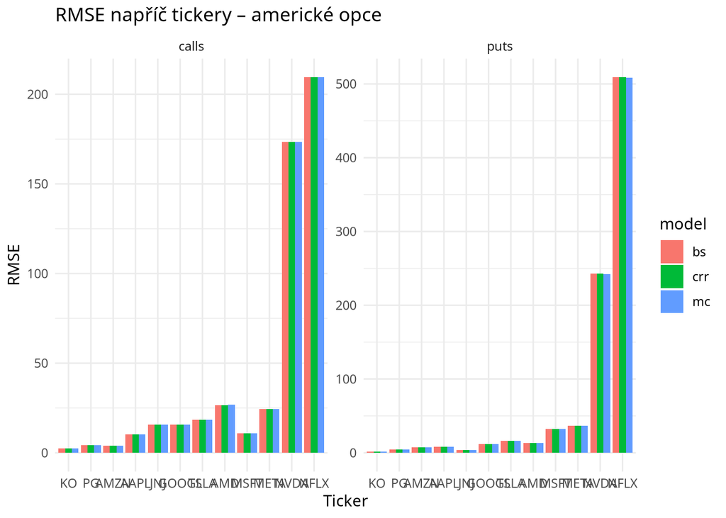

```r
df_model %>%
  filter(am_eu == "american") %>%
  mutate(abs_error = abs(true_price - teor_price)) %>%
  group_by(call_put, model, ticker) %>%
  summarise(RMSE = sqrt(mean((true_price - teor_price)^2, na.rm = TRUE)),
            .groups = "drop") %>%
  ggplot(aes(x = reorder(ticker, RMSE, mean), y = RMSE, fill = model)) +
  geom_col(position = "dodge") +
  facet_wrap(~ call_put, scales = "free_y") +
  labs(x = "Ticker", y = "RMSE", title = "RMSE napříč tickery – americké opce") +
  theme_minimal()
```

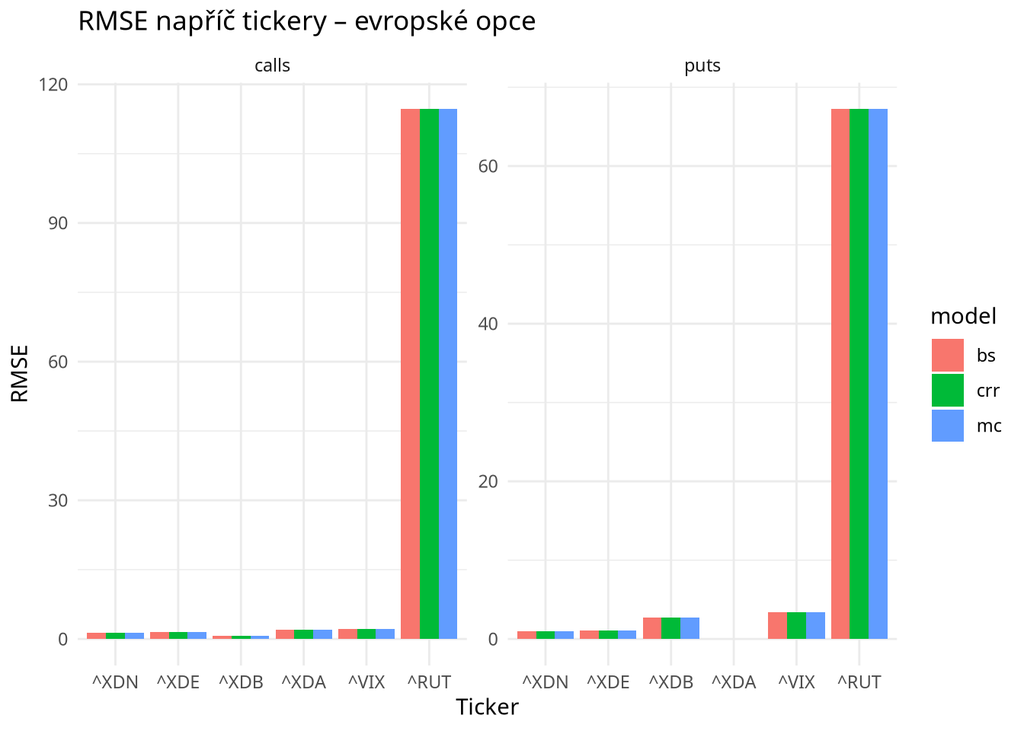

```r
ggsave("../figures/descriptive_rmse_by_ticker_american.pdf", width = 10, height = 6)
df_model %>%
  filter(am_eu == "european") %>%
  mutate(abs_error = abs(true_price - teor_price)) %>%
  group_by(call_put, model, ticker) %>%
  summarise(RMSE = sqrt(mean((true_price - teor_price)^2, na.rm = TRUE)),
            .groups = "drop") %>%
  ggplot(aes(x = reorder(ticker, RMSE, mean), y = RMSE, fill = model)) +
  geom_col(position = "dodge") +
  facet_wrap(~ call_put, scales = "free_y") +
  labs(x = "Ticker", y = "RMSE", title = "RMSE napříč tickery – evropské opce") +
  theme_minimal()
```

```r
ggsave("../figures/descriptive_rmse_by_ticker_european.pdf", width = 10, height = 6)
top_errors <- df_model %>%
  mutate(abs_error = abs(true_price - teor_price)) %>%
  arrange(desc(abs_error)) %>%
  slice_head(n = 25) %>%
  select(ticker, S, K, T, model, true_price, teor_price, abs_error)
kable(top_errors, digits = 4, caption = "Top 25 největších absolutních chyb")
```

Top 25 největších absolutních chyb

| ticker | S | K | T | model | true_price | teor_price | abs_error |
| --- | --- | --- | --- | --- | --- | --- | --- |
| NFLX | 84.59 | 2470 | 1.8055 | bs | 1138.30 | 2385.410 | 1247.110 |
| NFLX | 84.59 | 2470 | 1.8055 | crr | 1138.30 | 2385.410 | 1247.110 |
| NFLX | 86.12 | 2470 | 1.8932 | bs | 1138.30 | 2383.880 | 1245.580 |
| NFLX | 86.12 | 2470 | 1.8932 | crr | 1138.30 | 2383.880 | 1245.580 |
| NFLX | 84.59 | 2470 | 1.8055 | mc | 1138.30 | 2383.796 | 1245.496 |
| NFLX | 86.12 | 2470 | 1.8932 | mc | 1138.30 | 2382.192 | 1243.892 |
| NFLX | 88.60 | 2470 | 1.5644 | bs | 1138.30 | 2381.400 | 1243.100 |
| NFLX | 88.60 | 2470 | 1.5644 | crr | 1138.30 | 2381.400 | 1243.100 |
| NFLX | 88.60 | 2470 | 1.5644 | mc | 1138.30 | 2379.537 | 1241.237 |
| NFLX | 93.32 | 2470 | 1.7288 | bs | 1138.30 | 2376.680 | 1238.380 |
| NFLX | 93.32 | 2470 | 1.7288 | crr | 1138.30 | 2376.680 | 1238.380 |
| NFLX | 84.59 | 2070 | 0.8849 | bs | 747.46 | 1985.410 | 1237.950 |
| NFLX | 84.59 | 2070 | 0.8849 | crr | 747.46 | 1985.410 | 1237.950 |
| NFLX | 84.59 | 2070 | 0.8849 | mc | 747.46 | 1984.012 | 1236.552 |
| NFLX | 93.32 | 2470 | 1.7288 | mc | 1138.30 | 2374.851 | 1236.551 |
| NFLX | 86.12 | 2070 | 0.9726 | bs | 747.46 | 1983.880 | 1236.420 |
| NFLX | 86.12 | 2070 | 0.9726 | crr | 747.46 | 1983.880 | 1236.420 |
| NFLX | 86.12 | 2070 | 0.9726 | mc | 747.46 | 1982.477 | 1235.017 |
| NFLX | 88.60 | 2070 | 0.6438 | bs | 747.46 | 1981.400 | 1233.940 |
| NFLX | 88.60 | 2070 | 0.6438 | crr | 747.46 | 1981.400 | 1233.940 |
| NFLX | 88.60 | 2070 | 0.6438 | mc | 747.46 | 1979.887 | 1232.427 |
| NFLX | 93.32 | 2070 | 0.8082 | bs | 747.46 | 1976.680 | 1229.220 |
| NFLX | 93.32 | 2070 | 0.8082 | crr | 747.46 | 1976.680 | 1229.220 |
| NFLX | 93.32 | 2070 | 0.8082 | mc | 747.46 | 1975.183 | 1227.723 |
| NFLX | 84.59 | 2020 | 1.3041 | bs | 707.75 | 1935.410 | 1227.660 |

```r
top_errors_zero <- df_model %>%
  filter(teor_price == 0, model != "mc") %>%
  mutate(abs_error = abs(true_price - teor_price)) %>%
  arrange(desc(abs_error)) %>%
  slice_head(n = 25) %>%
  select(ticker, S, K, T, model, true_price, teor_price, abs_error)
kable(top_errors_zero, digits = 4, caption = "Top 25 největších absolutních chyb s teor_price = 0 (bez MC)")
```

Top 25 největších absolutních chyb s teor_price = 0 (bez MC)

| ticker | S | K | T | model | true_price | teor_price | abs_error |
| --- | --- | --- | --- | --- | --- | --- | --- |
| NFLX | 84.59 | 420 | 0.2137 | crr | 864.80 | 0 | 864.80 |
| NFLX | 93.32 | 420 | 0.1370 | crr | 864.80 | 0 | 864.80 |
| NFLX | 88.60 | 430 | 0.0658 | crr | 797.65 | 0 | 797.65 |
| NFLX | 88.60 | 470 | 0.0658 | crr | 789.50 | 0 | 789.50 |
| NFLX | 84.59 | 460 | 0.2137 | crr | 773.47 | 0 | 773.47 |
| NFLX | 93.32 | 460 | 0.1370 | crr | 773.47 | 0 | 773.47 |
| NFLX | 86.12 | 470 | 0.1479 | crr | 765.53 | 0 | 765.53 |
| NFLX | 84.59 | 470 | 0.0603 | crr | 765.53 | 0 | 765.53 |
| NVDA | 215.33 | 550 | 0.0658 | crr | 748.88 | 0 | 748.88 |
| NFLX | 88.60 | 480 | 0.0658 | crr | 745.90 | 0 | 745.90 |
| NFLX | 86.12 | 420 | 0.1479 | crr | 745.02 | 0 | 745.02 |
| NFLX | 84.59 | 420 | 0.0603 | crr | 745.02 | 0 | 745.02 |
| NVDA | 215.33 | 570 | 0.0658 | crr | 736.39 | 0 | 736.39 |
| NVDA | 215.33 | 630 | 0.0658 | crr | 721.20 | 0 | 721.20 |
| NVDA | 215.33 | 560 | 0.0658 | crr | 718.28 | 0 | 718.28 |
| NFLX | 93.32 | 520 | 0.2301 | crr | 712.50 | 0 | 712.50 |
| NFLX | 88.60 | 520 | 0.0658 | crr | 712.50 | 0 | 712.50 |
| NVDA | 215.33 | 520 | 0.0658 | crr | 711.59 | 0 | 711.59 |
| NFLX | 86.12 | 550 | 0.3014 | crr | 707.32 | 0 | 707.32 |
| NFLX | 84.59 | 550 | 0.2137 | crr | 707.32 | 0 | 707.32 |
| NFLX | 93.32 | 550 | 0.1370 | crr | 707.32 | 0 | 707.32 |
| NFLX | 86.12 | 530 | 0.1479 | crr | 706.25 | 0 | 706.25 |
| NFLX | 84.59 | 530 | 0.0603 | crr | 706.25 | 0 | 706.25 |
| NFLX | 84.59 | 580 | 0.3068 | crr | 705.97 | 0 | 705.97 |
| NFLX | 93.32 | 580 | 0.2301 | crr | 705.97 | 0 | 705.97 |

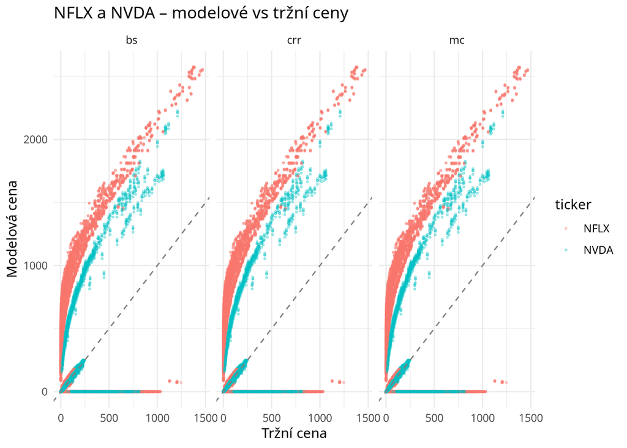

```r
df_model %>%
  filter(ticker %in% c("NFLX", "NVDA")) %>%
  ggplot(aes(x = true_price, y = teor_price, color = ticker)) +
  geom_point(alpha = 0.3, size = 0.5) +
  geom_abline(intercept = 0, slope = 1, linetype = "dashed", color = "gray50") +
  facet_wrap(~ model) +
  labs(x = "Tržní cena", y = "Modelová cena",
       title = "NFLX a NVDA – modelové vs tržní ceny") +
  theme_minimal()
```

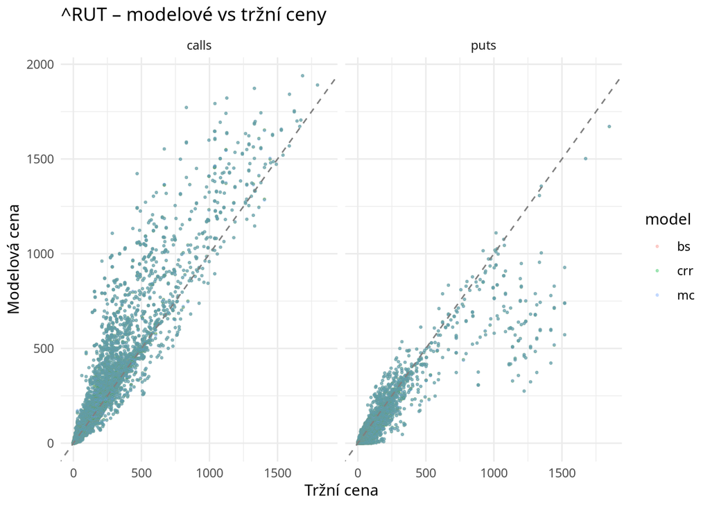

```r
ggsave("../figures/descriptive_scatter_nflx_nvda.pdf", width = 10, height = 4)
df_model %>%
  filter(ticker == "^RUT") %>%
  ggplot(aes(x = true_price, y = teor_price, color = model)) +
  geom_point(alpha = 0.3, size = 0.5) +
  geom_abline(intercept = 0, slope = 1, linetype = "dashed", color = "gray50") +
  facet_wrap(~ call_put) +
  labs(x = "Tržní cena", y = "Modelová cena",
       title = "^RUT – modelové vs tržní ceny") +
  theme_minimal()
```

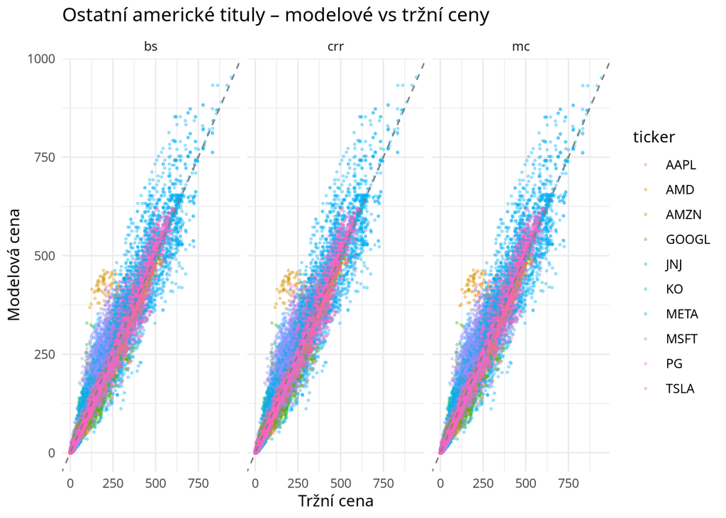

```r
ggsave("../figures/descriptive_scatter_rut.pdf", width = 10, height = 4)
df_model %>%
  filter(am_eu == "american", !ticker %in% c("NFLX", "NVDA")) %>%
  ggplot(aes(x = true_price, y = teor_price, color = ticker)) +
  geom_point(alpha = 0.3, size = 0.5) +
  geom_abline(intercept = 0, slope = 1, linetype = "dashed", color = "gray50") +
  facet_wrap(~ model) +
  labs(x = "Tržní cena", y = "Modelová cena",
       title = "Ostatní americké tituly – modelové vs tržní ceny") +
  theme_minimal()
```

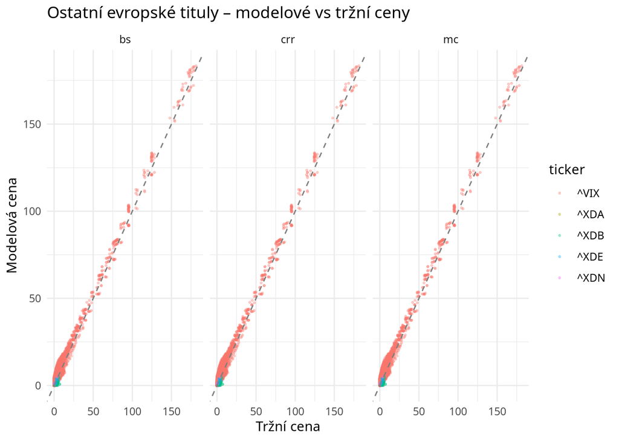

```r
ggsave("../figures/descriptive_scatter_american_remaining.pdf", width = 10, height = 5)
df_model %>%
  filter(am_eu == "european", ticker != "^RUT") %>%
  ggplot(aes(x = true_price, y = teor_price, color = ticker)) +
  geom_point(alpha = 0.3, size = 0.5) +
  geom_abline(intercept = 0, slope = 1, linetype = "dashed", color = "gray50") +
  facet_wrap(~ model) +
  labs(x = "Tržní cena", y = "Modelová cena",
       title = "Ostatní evropské tituly – modelové vs tržní ceny") +
  theme_minimal()
```

```r
ggsave("../figures/descriptive_scatter_european_remaining.pdf", width = 10, height = 5)
```